# Physical Activity Prediction from Wearable Sensors

Dominic Arcona

2023-12-01

### Introduction

Wearable sensors are increasingly used to monitor health and physical activity. This project investigates whether inertial and physiological signals collected from wearable devices can accurately classify physical activities.

## Goals

- Predict 13 physical activity classes from wearable sensor data
- Compare multiple classification models
- Evaluate feature importance
- Assess how predictive performance changes when using sensors from only one body location

## Data

The PAMAP2 dataset [Reiss, A. (2012). PAMAP2 Physical Activity Monitoring [Dataset]. UCI Machine Learning Repository. https://doi.org/10.24432/C5NW2H.] is the base data source. Diego Silva compiled the data into a CSV file available for download at https://www.kaggle.com/datasets/diegosilvadefrana/fisical-activity-dataset/data. We dowloaded and stored ‘dataset2.csv’ in the project root. The dataset contains observations from 8 participants in a 2012 study. Heart rate and inertial data was collected several times per second over the course of about 3600 seconds per participant. The total number of observations in the dataset is over 2.86 million. There are 31 predictors available plus the response variable and a PeopleID. The predictors include variables such as heart rate, temperature, and inertial measurements recorded at the chest, wrist, and ankle. The response variable is the type of activity being performed. There are 13 unique responses including ‘transient activity’, which is intended to capture states in which none of the other 12 physical activities are being performed.

### Import Libraries and Data

### Exploratory Analysis

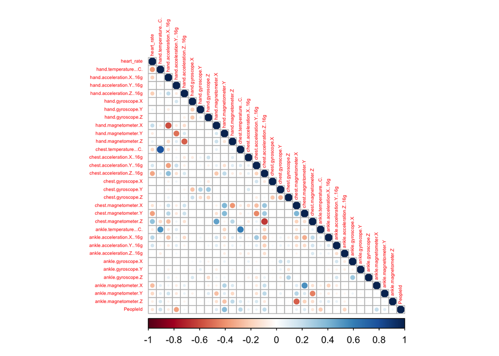

Strong correlations appear among temperature sensors and between accelerometer–magnetometer pairs at the same body location.

## Scaled Heart Rate

First, we want to scale our heart_rate feature to account for the fact that different people have different max heart rates and different levels of fitness that may cause their heart rates to differ significantly when they are performing the same task.

## Body Temperature

Since the body part temperature variables are strongly correlated, we will combine these into a single body_temperature variable.

## Box Plots

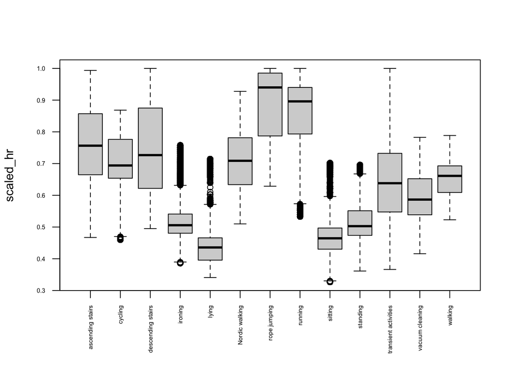

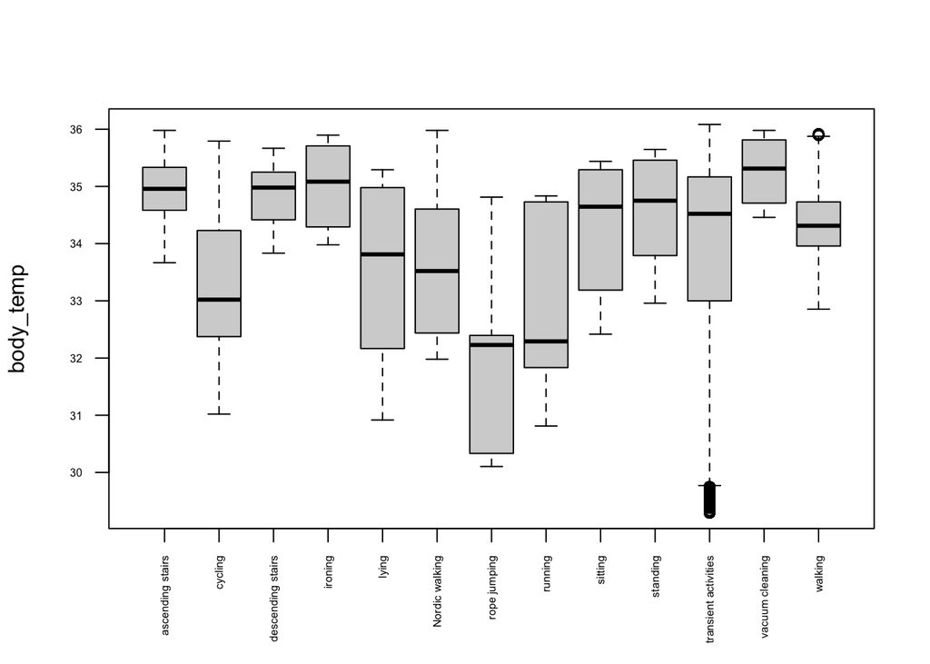

Participants’ heart rates vary widely even within activities, but scaled_hr should still be a strong predictive variable. We expect body_temp to also be strongly predictive, and are pleasantly surprised to see that it is not highly correlated with heart rate. Notice ‘rope jumping’ as an example of an activity associated with very high heart rate, but low body temperature. This could be an indication that intense activity like jumping interferes with temperature sensor function, but it is nonetheless useful for activity classification.

### Train / Test Split

We evaluate models using a random train–test split with fixed sample size. This choice reflects our goal of assessing instantaneous activity separability rather than temporal or subject-level generalization. Random sampling preserves the activity distribution and class imbalance while providing large, representative training and test sets. A fixed sample size ensures computational tractability and fair comparison across models. All splits are generated with a fixed random seed to ensure reproducibility.

### Handling Class Imbalance

Rebalancing class weights will help our models assign more equal importance to different classes regardless of their rate of occurrence in the data.

### Multinomial Logistic Regression

Here we notice that the runtime is a bit excessive, so we constrain our model to use the 3 most powerful predictors (previously determined through separate analysis).

```
## Confusion Matrix and Statistics
##
##                       Reference
## Prediction             ascending stairs cycling descending stairs ironing lying
##   ascending stairs                    0       0                 0       0     0
##   cycling                            70     987                50       0     1
##   descending stairs                   0       0                 0       0     0
##   ironing                             3       7                 0     115    38
##   lying                               0       0                 0       0 12105
##   Nordic walking                      0       0                 0       0     0
##   rope jumping                        0       0                 0       0     0
##   running                             0       0                 0       0     0
##   sitting                             0       0                 0     122   367
##   standing                            0       0                 0       0     0
##   transient activities             8062   10282              7134   16419  1011
##   vacuum cleaning                   171      75                65      25     1
##   walking                             0       0                 0       0     0
##                       Reference
## Prediction             Nordic walking rope jumping running sitting standing
##   ascending stairs                  0            1       0       0        0
##   cycling                         170          280     384       6        0
##   descending stairs                 0            0       0       0        0
##   ironing                           0            0       0      45        0
##   lying                             6           33      15     542        0
##   Nordic walking                    0            0       0       0        0
##   rope jumping                      0            0       0       0        0
##   running                           0           35      24       0        0
##   sitting                           0            0       0    3444     1233
##   standing                          0            0       0       0        0
##   transient activities          12815         2746    6388    8903    12058
##   vacuum cleaning                   7            0       1       8        1
##   walking                           0            0       0       0        0
##                       Reference
## Prediction             transient activities vacuum cleaning walking
##   ascending stairs                        0               0       0
##   cycling                               187             404      46
##   descending stairs                       0               0       0
##   ironing                               306              32       0
##   lying                                   1               0       0
##   Nordic walking                          0               0       0
```

[output cut: 51 more lines]

```
## Pos Pred Value              0.59492             NaN                      0.3601
## Neg Pred Value              0.95106         0.93354                      0.9428
## Prevalence                  0.06474         0.06646                      0.3239
## Detection Rate              0.01722         0.00000                      0.3170
## Detection Prevalence        0.02894         0.00000                      0.8804
## Balanced Accuracy           0.62673         0.50000                      0.5728
##                      Class: vacuum cleaning Class: walking
## Sensitivity                        0.133524        0.00000
## Specificity                        0.996762        1.00000
## Pos Pred Value                     0.728693            NaN
## Neg Pred Value                     0.946415        0.91628
## Prevalence                         0.061150        0.08372
## Detection Rate                     0.008165        0.00000
## Detection Prevalence               0.011205        0.00000
## Balanced Accuracy                  0.565143        0.50000
```

The results are not too impressive. Even with the provided class weights, the model mostly predicts ‘transient activities’.

### Random Forest Classifier

Let’s train a random forest classifier next.

```
## Confusion Matrix and Statistics
##
##                       Reference
## Prediction             ascending stairs cycling descending stairs ironing lying
##   ascending stairs                 7157       3                62       0     0
##   cycling                             2   11153                19       8     0
##   descending stairs                  49       3              5952       0     0
##   ironing                             0       0                 2   16579     2
##   lying                               0       0                 0       0 13460
##   Nordic walking                     22       1                10       0     0
##   rope jumping                        0       1                 0       0     0
##   running                             8       0                 2       0     0
##   sitting                             0       0                 0       0     0
##   standing                            0       0                 0      37     0
##   transient activities              971     183              1162      53    57
##   vacuum cleaning                    50       7                16       4     4
##   walking                            47       0                24       0     0
##                       Reference
## Prediction             Nordic walking rope jumping running sitting standing
##   ascending stairs                  4            2       1       0        0
##   cycling                           1            2       0       0        0
##   descending stairs                 1            0       2       0        0
##   ironing                           0            0       0       0       22
##   lying                             0            0       0       0        0
##   Nordic walking                12710            2       2       0        0
##   rope jumping                      0         2918       0       0        0
##   running                           1           13    6711       0        0
##   sitting                           0            0       0   12849        3
##   standing                          0            0       0      11    13187
##   transient activities            226          158      91      77       78
##   vacuum cleaning                   0            0       0      11        2
##   walking                          55            0       5       0        0
##                       Reference
## Prediction             transient activities vacuum cleaning walking
##   ascending stairs                      234               1       6
##   cycling                                56               9       0
##   descending stairs                     152               0       6
##   ironing                                55              34       2
##   lying                                  12               0       0
##   Nordic walking                         56               2      62
```

[output cut: 51 more lines]

```
## Pos Pred Value              0.99891         0.99607                      0.9389
## Neg Pred Value              0.99947         0.99944                      0.9928
## Prevalence                  0.06474         0.06646                      0.3239
## Detection Rate              0.06424         0.06593                      0.3191
## Detection Prevalence        0.06431         0.06620                      0.3399
## Balanced Accuracy           0.99614         0.99591                      0.9773
##                      Class: vacuum cleaning Class: walking
## Sensitivity                         0.94440        0.96763
## Specificity                         0.99906        0.99780
## Pos Pred Value                      0.98491        0.97573
## Neg Pred Value                      0.99639        0.99704
## Prevalence                          0.06115        0.08372
## Detection Rate                      0.05775        0.08101
## Detection Prevalence                0.05863        0.08303
## Balanced Accuracy                   0.97173        0.98272
```

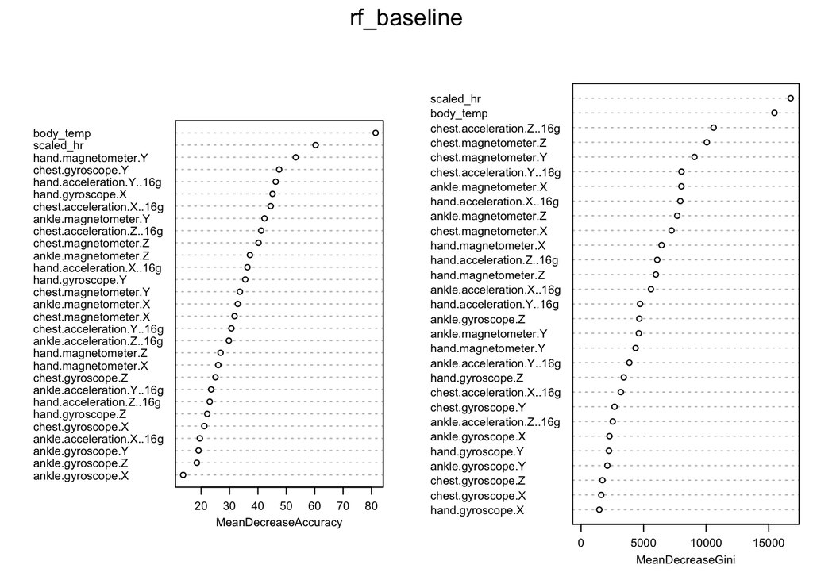

With accuracy over 97%, this model baseline model is quite impressive.

### Reduced Feature Random Forest

For a more fair comparison with the multinomial logistic regression model, let’s train a random forest classifier on the same 3 predictors.

```
## Confusion Matrix and Statistics
##
##                       Reference
## Prediction             ascending stairs cycling descending stairs ironing lying
##   ascending stairs                 6257      41               163       0     0
##   cycling                           105   10884                48       0     0
##   descending stairs                 248      12              6089      22     0
##   ironing                            11       0                76   16173     5
##   lying                               0       0                 0       0 13408
##   Nordic walking                    248      53                33       7     3
##   rope jumping                        0       0                 1       0     0
##   running                             9      14                 0       0     0
##   sitting                             3       1                 0       2    39
##   standing                           21       0                 7      32     3
##   transient activities              951     265               692     321    48
##   vacuum cleaning                   201      12                16      44     0
##   walking                           252      69               124      80    17
##                       Reference
## Prediction             Nordic walking rope jumping running sitting standing
##   ascending stairs                 58            1      16       0        2
##   cycling                          56           12      64      11        0
##   descending stairs                13            0       0       1        2
##   ironing                           2            0       0       9       37
##   lying                             0            0       3       5        0
##   Nordic walking                12308           38      12       6        1
##   rope jumping                      1         2637      66       0        0
##   running                           5          173    5951       0        1
##   sitting                          17            0       0   12652       45
##   standing                         11            0      17      42    13039
##   transient activities            420          234     663     191      105
##   vacuum cleaning                  63            0       7       1        0
##   walking                          44            0      13      30       60
##                       Reference
## Prediction             transient activities vacuum cleaning walking
##   ascending stairs                      283              31     108
##   cycling                               194              12      92
##   descending stairs                     342               5      43
##   ironing                               447             236     122
##   lying                                  34               0       4
##   Nordic walking                        297              30      81
```

[output cut: 51 more lines]

```
## Pos Pred Value              0.98062         0.97118                      0.9190
## Neg Pred Value              0.99842         0.99864                      0.9753
## Prevalence                  0.06474         0.06646                      0.3239
## Detection Rate              0.06326         0.06520                      0.3074
## Detection Prevalence        0.06451         0.06713                      0.3345
## Balanced Accuracy           0.98790         0.98945                      0.9546
##                      Class: vacuum cleaning Class: walking
## Sensitivity                         0.92061        0.91280
## Specificity                         0.99609        0.99245
## Pos Pred Value                      0.93880        0.91697
## Neg Pred Value                      0.99484        0.99204
## Prevalence                          0.06115        0.08372
## Detection Rate                      0.05629        0.07642
## Detection Prevalence                0.05996        0.08334
## Balanced Accuracy                   0.95835        0.95263
```

The overall accuracy of 93.8% is very impressive compared to the logit model. We hypothesize that different activity regions in the predictor space cannot be linearly separated but can be separated reasonably well using decision trees.

### Exercise vs. Non-Exercise Classification

## Activity Regrouping

### Random Forest Classifcation on Re-grouped Activities

```
## Confusion Matrix and Statistics
##
##                       Reference
## Prediction             cycling Nordic walking rope jumping running
##   cycling                11336              0            0       0
##   Nordic walking             0          12966            0       0
##   rope jumping               0              0         2854       0
##   running                    1              0           13    6763
##   stair climbing             6              1            0       0
##   transient activities     124             86          101      94
##   walking                    1              0            0       1
##                       Reference
## Prediction             stair climbing transient activities walking
##   cycling                           0                   28       0
##   Nordic walking                    0                   34       7
##   rope jumping                      0                   11       0
##   running                           0                    7       1
##   stair climbing                14993                  105       0
##   transient activities            487               133472     195
##   walking                           4                   28   16281
##
## Overall Statistics
##
##                Accuracy : 0.9933
##                  95% CI : (0.993, 0.9937)
##     No Information Rate : 0.6684
##     P-Value [Acc > NIR] : < 2.2e-16
##
##                   Kappa : 0.9874
##
##  Mcnemar's Test P-Value : NA
##
## Statistics by Class:
##
##                      Class: cycling Class: Nordic walking Class: rope jumping
## Sensitivity                 0.98849               0.99333             0.96159
## Specificity                 0.99985               0.99978             0.99994
## Pos Pred Value              0.99754               0.99685             0.99616
## Neg Pred Value              0.99930               0.99953             0.99942
## Prevalence                  0.05734               0.06527             0.01484
## Detection Rate              0.05668               0.06483             0.01427
## Detection Prevalence        0.05682               0.06503             0.01432
## Balanced Accuracy           0.99417               0.99656             0.98077
##                      Class: running Class: stair climbing
## Sensitivity                 0.98615               0.96829
## Specificity                 0.99989               0.99939
## Pos Pred Value              0.99676               0.99259
## Neg Pred Value              0.99951               0.99734
## Prevalence                  0.03429               0.07742
## Detection Rate              0.03381               0.07497
## Detection Prevalence        0.03392               0.07552
## Balanced Accuracy           0.99302               0.98384
##                      Class: transient activities Class: walking
## Sensitivity                               0.9984        0.98769
## Specificity                               0.9836        0.99981
## Pos Pred Value                            0.9919        0.99792
## Neg Pred Value                            0.9967        0.99889
## Prevalence                                0.6684        0.08242
## Detection Rate                            0.6674        0.08141
## Detection Prevalence                      0.6728        0.08157
## Balanced Accuracy                         0.9910        0.99375
```

### Comparison to full multiclass random forest

| Model | Accuracy |
| --- | --- |
| Original Labels | 0.971235 |
| Re-grouped Labels | 0.993325 |

```
## $Baseline_Recall
##     Class: ascending stairs              Class: cycling
##                   0.8616663                   0.9825566
##    Class: descending stairs              Class: ironing
##                   0.8210788                   0.9938853
##                Class: lying       Class: Nordic walking
##                   0.9953413                   0.9778427
##         Class: rope jumping              Class: running
##                   0.9428110                   0.9851732
##              Class: sitting             Class: standing
##                   0.9923540                   0.9921005
## Class: transient activities      Class: vacuum cleaning
##                   0.9853021                   0.9443990
##              Class: walking
##                   0.9676302
##
## $Regrouped_Recall
##              Class: cycling       Class: Nordic walking
##                   0.9884897                   0.9933349
##         Class: rope jumping              Class: running
##                   0.9615903                   0.9861476
##       Class: stair climbing Class: transient activities
##                   0.9682898                   0.9984067
##              Class: walking
##                   0.9876850
```

### Binary Exercise vs. Non-Exercise Classification

Let’s train a model that simply predicts whether or not a wearer is engaged in deliberate exercise.

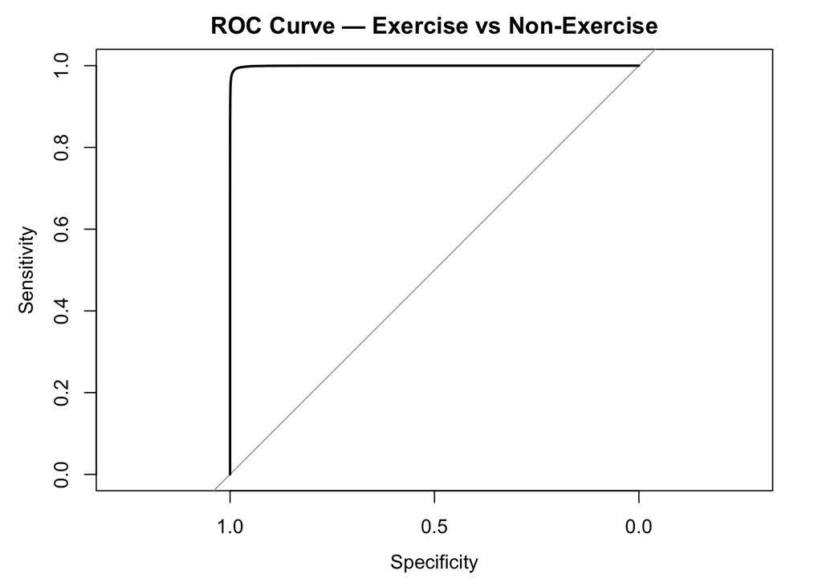

```
## Area under the curve: 0.9995
```

### Sensor Location Comparison

In the real world, consumers are unlikely to wear multiple sensors. In this section, we will attempt to answer the question: “Where should one wear the sensor for best activity predictive performance?”. Let’s train models using only chest, ankle, or wrist-collected variables and compare performance.

```r
# IMPORTANT:
# We previously created body_temp for global models, but for location-specific
# models we must retain and use the *location-specific temperature sensor*.
# This block constructs fair single-location datasets that include:
#   - inertial sensors from that location
#   - the corresponding temperature sensor
#   - scaled heart rate (global)

make_location_df <- function(prefix, temp_var) {
  vars <- c(
    "activityID",
    "scaled_hr",
    "PeopleId",
    temp_var,
    grep(paste0("^", prefix, "\\."), names(df), value = TRUE)
  )
  df[, unique(vars)]
}

df_hand  <- make_location_df("hand",  "hand.temperature...C.")
df_chest <- make_location_df("chest", "chest.temperature...C.")
df_ankle <- make_location_df("ankle", "ankle.temperature...C.")

fit_sensor_rf <- function(d) {
  d$activityID <- as.factor(d$activityID)

  idx <- sample(nrow(d), n)
  train <- d[idx, ] %>% select(-PeopleId)
  test  <- d[-idx, ] %>% sample_n(n) %>% select(-PeopleId)

  cw <- train %>%
    count(activityID) %>%
    mutate(weight = sum(n) / (length(n) * n)) %>%
    deframe()

  rf <- randomForest(
    activityID ~ .,
    data = train,
    ntree = 100,
    classwt = cw
  )

  confusionMatrix(predict(rf, test), test$activityID)
}

fit_sensor_rf(df_hand)
```

```
## Confusion Matrix and Statistics
##
##                       Reference
## Prediction             ascending stairs cycling descending stairs ironing lying
##   ascending stairs                 6949      12                89       0     0
##   cycling                             6   11195                14       0     0
##   descending stairs                 125       6              6204       5     0
##   ironing                             4       0                60   16410     3
##   lying                               0       0                 0       2 13170
##   Nordic walking                     20      31                13       0     0
##   rope jumping                        1       1                 0       0     0
##   running                            11       4                 3       0     0
##   sitting                             3       0                 0       0     4
##   standing                            2       0                 0      25     0
##   transient activities              880     239               775     288   108
##   vacuum cleaning                   102       5                72      22     2
##   walking                            55      24                10       0     1
##                       Reference
## Prediction             Nordic walking rope jumping running sitting standing
##   ascending stairs                  9            1      11       0        0
##   cycling                          14            8       0       0        0
##   descending stairs                 9            2       4       0        1
##   ironing                           5            0       0       5       61
##   lying                             0            0       0       1        0
##   Nordic walking                12847           16       4       0        1
##   rope jumping                      0         2838       7       0        0
##   running                           7           50    6637       0        0
##   sitting                           0            0       0   12843       14
##   standing                          0            0       0      22    12800
##   transient activities            237          129     158     108      223
##   vacuum cleaning                   0            0       3       0       14
##   walking                          25            2      10       5        1
##                       Reference
## Prediction             transient activities vacuum cleaning walking
##   ascending stairs                       91               4       0
##   cycling                               173              16      16
##   descending stairs                     120              13       2
##   ironing                               382             117       2
##   lying                                  14               0       0
##   Nordic walking                        192               0      58
```

[output cut: 51 more lines]

```
## Pos Pred Value              0.99651         0.99248                      0.9380
## Neg Pred Value              0.99925         0.99832                      0.9868
## Prevalence                  0.06492         0.06557                      0.3248
## Detection Rate              0.06421         0.06400                      0.3160
## Detection Prevalence        0.06444         0.06449                      0.3369
## Balanced Accuracy           0.99445         0.98773                      0.9710
##                      Class: vacuum cleaning Class: walking
## Sensitivity                         0.93392        0.97094
## Specificity                         0.99726        0.99717
## Pos Pred Value                      0.95672        0.96920
## Neg Pred Value                      0.99573        0.99734
## Prevalence                          0.06084        0.08395
## Detection Rate                      0.05681        0.08151
## Detection Prevalence                0.05939        0.08410
## Balanced Accuracy                   0.96559        0.98405
```

```r
fit_sensor_rf(df_chest)
```

```
## Confusion Matrix and Statistics
##
##                       Reference
## Prediction             ascending stairs cycling descending stairs ironing lying
##   ascending stairs                 6735      44               153       0     0
##   cycling                            87   11212                 0       2     0
##   descending stairs                 124       0              5863       0     0
##   ironing                            10       2                 0   16326     4
##   lying                               0       0                 0       0 13440
##   Nordic walking                     20      25                 9       3     0
##   rope jumping                        1       0                 0       0     0
##   running                             2       1                12       0     0
##   sitting                             0       0                 0       0     2
##   standing                            0       0                 0      40     0
##   transient activities              908     204              1114      63    91
##   vacuum cleaning                    65       9                40       5     6
##   walking                            88      21                68       5     0
##                       Reference
## Prediction             Nordic walking rope jumping running sitting standing
##   ascending stairs                 16            1      17       0        0
##   cycling                          37            3       4       1        0
##   descending stairs                 4            0      25       0        0
##   ironing                          17            0       0       3       46
##   lying                             0            0       0       0        0
##   Nordic walking                12860            5       4       2        0
##   rope jumping                      0         2835       1       0        0
##   running                           2           26    6718       0        0
##   sitting                           0            0       0   12812        4
##   standing                          0            0       0      25    13324
##   transient activities            276          128     154      52       61
##   vacuum cleaning                   5            0       4      10        1
##   walking                          29            0      14       0        0
##                       Reference
## Prediction             transient activities vacuum cleaning walking
##   ascending stairs                      256               2       9
##   cycling                                91              18      13
##   descending stairs                     150               1       7
##   ironing                               187              50       8
##   lying                                  14               0       0
##   Nordic walking                        126               8      34
```

[output cut: 51 more lines]

```
## Pos Pred Value              0.99728         0.99307                      0.9358
## Neg Pred Value              0.99950         0.99940                      0.9882
## Prevalence                  0.06452         0.06718                      0.3217
## Detection Rate              0.06406         0.06662                      0.3139
## Detection Prevalence        0.06424         0.06709                      0.3354
## Balanced Accuracy           0.99630         0.99558                      0.9719
##                      Class: vacuum cleaning Class: walking
## Sensitivity                         0.95363        0.94720
## Specificity                         0.99806        0.99604
## Pos Pred Value                      0.97034        0.95652
## Neg Pred Value                      0.99692        0.99515
## Prevalence                          0.06243        0.08418
## Detection Rate                      0.05954        0.07974
## Detection Prevalence                0.06136        0.08336
## Balanced Accuracy                   0.97585        0.97162
```

```r
fit_sensor_rf(df_ankle)
```

```
## Confusion Matrix and Statistics
##
##                       Reference
## Prediction             ascending stairs cycling descending stairs ironing lying
##   ascending stairs                 6199      13               151       1     0
##   cycling                           103   10711                27       1     0
##   descending stairs                 161       1              5664       0     0
##   ironing                             3       2                 1   16793     0
##   lying                               1       0                 0       0 13409
##   Nordic walking                    133      71                24       0     0
##   rope jumping                        1       0                 1       0     0
##   running                            30       2                47       0     0
##   sitting                             1       0                 0       0     2
##   standing                            0       1                 0      96     0
##   transient activities             1405     486              1377     105   107
##   vacuum cleaning                    78      13                40       2     1
##   walking                            69      23               136       3     0
##                       Reference
## Prediction             Nordic walking rope jumping running sitting standing
##   ascending stairs                 14            7       8       0        0
##   cycling                          30           16      33       0        0
##   descending stairs                 4            3      16       0        0
##   ironing                           1            0       0       0       32
##   lying                             0            0       0       0        0
##   Nordic walking                12587            2      42       0        0
##   rope jumping                      0         2786       6       0        0
##   running                           3           29    6255       0        0
##   sitting                           0            0       0   12925       21
##   standing                          0            0       1       7    13025
##   transient activities            349          156     285      60      112
##   vacuum cleaning                   4            0       0      13       15
##   walking                         156            0      41       0        0
##                       Reference
## Prediction             transient activities vacuum cleaning walking
##   ascending stairs                      321              17       1
##   cycling                               326              26      27
##   descending stairs                     203               7       8
##   ironing                               128              21       3
##   lying                                  18               0       2
##   Nordic walking                        161               3     120
```

[output cut: 51 more lines]

```
## Pos Pred Value              0.99469         0.98869                      0.9147
## Neg Pred Value              0.99957         0.99904                      0.9834
## Prevalence                  0.06502         0.06603                      0.3230
## Detection Rate              0.06463         0.06513                      0.3121
## Detection Prevalence        0.06497         0.06587                      0.3412
## Balanced Accuracy           0.99674         0.99279                      0.9616
##                      Class: vacuum cleaning Class: walking
## Sensitivity                         0.92841        0.95141
## Specificity                         0.99780        0.99418
## Pos Pred Value                      0.96500        0.93667
## Neg Pred Value                      0.99533        0.99560
## Prevalence                          0.06132        0.08294
## Detection Rate                      0.05693        0.07891
## Detection Prevalence                0.05899        0.08425
## Balanced Accuracy                   0.96310        0.97280
```

We conclude that wearing the sensor on one’s wrist or chest can yield superior activity prediction compared to wearing the sensor on one’s ankle based on the results above. All three models remain highly predictive, with 95+% accuracy, so that is encouraging for consumers who do not want to wear multiple sensors.

### Conclusions and Future Work

We find that random forest classifiers have a great deal of predictive power for activity classification based on these data. This is an exciting finding and it matches our personal experience with WHOOP, which is subjectively quite good at identifying different deliberate-exercise activities performed in daily life. There are two main areas from which we expect future improvements to stem. One is tuning model hyperparameters and increasing computing power behind the models. Only the default number of variables to consider at each split was implemented (mtry=$\sqrt{p}$). Additionally, we were only able to train random forest classifiers with 100 trees, which is below the default 500. Increasing the number of trees led to runtime difficulties. Another area for future improvement would be to leverage the time-series nature of these data. One could imagine training a model biased towards continuing to predict the same class of activity (as it moves through time), so that only a significant shift in the predictors would cause it to re-assess which activity is being performed. This tracks more closely with our experience of activities on a human timescale. We are not biking one moment and rope jumping the next! Therefore if the model predicts that we are biking for several small time chunks in a row, and then predicts rope jumping for a few time chunks before returning to predicting biking, it has likely made an error.

With such encouraging results from our physical activity prediction, we are also curious about other potential applications of wearable sensors. Professors and graduate students in the USC mathematics department, including Professor Goldstein, have previously investigated an application of wearable sensor technology to blood alcohol content (BAC) prediction using only data available at the skin surface. Another potential application could be in the field of emergency response. For example, if a wearable sensor on an aging parent were able to accurately detect that they had been sitting or lying down for an extended period of time, that might trigger a series of notifications, possibly including to family members, before resulting in a call to emergency response services.

### Repository Notes

-Dataset CSV file available at https://www.kaggle.com/datasets/diegosilvadefrana/fisical-activity-dataset/data -Code assumes dataset2.csv in project root -Results reproducible with set.seed(1)